# Example SOCfinder analysis

Anna Dewar & Laurie Belcher

08/08/2023

# 1 Overview of the analysis

In this example analysis, we will use SOCfinder to find cooperative genes in complete bacterial genomes from a number of different species. Specifically, our aim will be to locate the cooperative genes using SOCfinder, identify if they are located on the chromosome(s) or a plasmid(s), count up the number for each genome, and then generate a final dataset with which to do further data analsyis.

For more information on why we would want to do this kind of analysis, please see this [2021 paper by Dewar *et al.*](https://www.nature.com/articles/s41559-021-01573-2), which used a similar approach across 51 bacterial species, using PSORTb to locate extracellular proteins.

# 2 Genomes

## 2.1 Selecting genomes

We will download genomes from all species which have 10 or more complete genomes available that have 1 or more plasmid sequences.

Therefore, we need to work out which species meet this criteria, and then get a list of accession numbers of the genomes we need to download.

We used the table of all prokaryote genomes available on NCBI to find all species which matched these criteria (table available to download [here](https://www.ncbi.nlm.nih.gov/genome/browse/#!/prokaryotes/)).

Note: We will want to download the RefSeq version of the assembly, which has an accession number starting with GCF_, rather than the GenBank version which begins with GCA_. At the end of the below code, we replace the ‘A’ with an ‘F’ when creating the list of accessions which we use in the next section to download the genomes. There were a few cases where the RefSeq version number was lower than the GenBank version (i.e. GCA_000241585.3 in GenBank, GCF_000241585.2 in RefSeq). In these cases, we corrected the accession number so we could download those RefSeq assemblies.

**Code: click to expand**

```r
## Initial data ----
# Read in list of all prokaryote genomes
prokaryotes <- fread("prokaryotes.txt")

# Remove Archaea
archaea <- fread("ncbi_dataset_archaea.tsv")

archaea_species_names <- archaea %>%
  mutate(species_binomial = word(Organism_Name, 1,2, sep=" "))

## Selecting Refseq genomes ----
# Filter refseq genomes to include only complete genomes & those with NZ/NC accessions
prokaryotes_complete <- prokaryotes %>%
  filter(Status=="Complete Genome")

prokaryotes_complete_ref_seq <- prokaryotes_complete %>%
  filter(grepl("NC|NZ", Replicons))

# filter to include only those containing a plasmid
prokaryotes_plasmids <- prokaryotes_complete_ref_seq %>%
  filter(grepl("plasmid", Replicons))

## Extracting species name & chr accession ----
prokaryotes_species_name <- prokaryotes_plasmids %>%
  mutate(species_binomial = word(Organism_Name, 1,2, sep=" "))

prokaryotes_species_accession <- prokaryotes_species_name %>%
  mutate(accession1 = word(Replicons, 2, sep=":"), accession2 = word(accession1, 1, sep=";"),
         chr_accession_number = word(accession2, 1, sep="/"),
         chr_accession_number_no_version = word(chr_accession_number, 1, sep=fixed(".")))

bacteria <- anti_join(prokaryotes_species_accession, archaea_species_names, by=join_by(species_binomial))

# Removes small number of genomes that don't have a full chromosome/plasmid assembly
bacteria_quality_check <- bacteria %>%
  filter(grepl("NC|NZ", chr_accession_number_no_version))

## Filtering genomes ----
# Count number of genomes per species
bacteria_species_count <- bacteria_quality_check %>%
  count(species_binomial)

# Filter so only include those with >=10 genomes per species
# Features 148 species
bacteria_species_count_10 <- bacteria_species_count %>%
  filter(n >= 10) %>%
  filter(!grepl(" sp.", species_binomial)) # Remove species not with full binomial names


# Filter detailed file so only includes info on species from those 148 species
bacteria_species_10_details <- bacteria_quality_check %>%
  filter(species_binomial %in% bacteria_species_count_10$species_binomial)

## Selecting genomes ----
# If number of genomes >100, randomly select up to 100 genomes for these species
bacteria_species_10_details_random_100 <- bacteria_species_10_details %>%
  group_by(species_binomial) %>%
  slice_sample(n=100)

bacteria_species_10_details_random_100_tidy <- bacteria_species_10_details_random_100 %>%
  rename_with(make.names)

## List of genome accessions ----
## Input file for downloading accessions

# Want to download the refseq version of the genomes
substring(bacteria_species_10_details_random_100_tidy$Assembly.Accession, 3, 3) <- "F"


accession_input_file_148_species_100 <- as.data.frame(bacteria_species_10_details_random_100_tidy) %>%
  select(Assembly.Accession)

## Write list of accessions to txt file - will call in bash script 'bash_script_download_genomes.sh'
write.table(accession_input_file_148_species_100, "accessions_148_species_100.txt", col.names=F, row.names=F, quote=F)
```

## 2.2 Downloading genomes from NCBI

The easiest way to download lots of genomes at once is to use the NCBI Datasets tool. We used the conda package version which can be installed [here](https://www.ncbi.nlm.nih.gov/datasets/docs/v2/download-and-install/).

We can use a bash script like the one below to use the Datasets conda package to download every genome in the list of accession numbers. These will be downloaded all together into a .zip folder, which you should then unzip. You’ll find a folder for each genome accession, each containing three files: .fna, .faa and .gff.

We recommend downloading the RefSeq version of an assembly where possible (begins with GCF_, while GenBank version begins with GCA_). For more info, please see [this answered FAQ](https://www.ncbi.nlm.nih.gov/datasets/docs/v2/troubleshooting/faq/#what-is-the-difference-between-a-genbank-gca-and-refseq-gcf-genome-assembly) on the NCBI website.

**Code: click to expand**

```bash
#!/bin/bash
## Bash script to download things
for i in $(cat Path/to/file/accessions_148_species_100.txt)
do
echo ${i}
datasets download genome accession ${i} --include gff3,genome,protein --filename ${i}.zip
done
```

There were fewer genome accessions in the folder than we expected, indicating a few had issues downloading. To investigate, we ran the following command in the command line:

**Code: click to expand**

```bash
# Get a list of all genomes do
ls genomes_148_species/ncbi_dataset/data > filenames.txt
```

This gives a list of all the accessions which have been downloaded. We then loaded this up into R, and matched it to the original list to see which still need to be downloaded:

**Code: click to expand**

```r
## See which genomes didn't download
downloaded_genomes <- fread("filenames.txt")

setnames(downloaded_genomes, "Assembly.Accession")

undownloaded_genomes <- anti_join(accession_input_file_148_species_100, downloaded_genomes)

## Save these as a .txt
write.table(undownloaded_genomes, "undownloaded_genomes.txt", col.names=F, row.names=F, quote=F)
```

We then repeated the above steps of downloading the genomes using the Datasets conda package, then unzipping them. We copied these genome folders into the original folder so they were all together.

There were 5 genomes that were no longer listed in the NCBI database, and so we were unable to download these. These were all from the species *Staphylococcus xylosus*, meaning it no longer had 10 or more genomes in our dataset. Therefore, we removed this species from our dataset, leaving us with 147 species for further analysis.

**Code: click to expand**

```r
## Finally see which have been downloaded (5 that haven't)
## Do again to check which not there
downloaded_genomes <- fread("filenames.txt")

setnames(downloaded_genomes, "Assembly.Accession")

bacteria_148_species_100_downloaded <- semi_join(bacteria_species_10_details_random_100_tidy, downloaded_genomes)

## See how that affects genome counts per species
bacteria_148_species_100_downloaded_count <- bacteria_148_species_100_downloaded %>%
  count(species_binomial)

## Upon examination, one species Staphylococcus xylosus now has only 6 genomes
## Will remove genomes of this species
bacteria_147_species_100_downloaded <- bacteria_148_species_100_downloaded %>%
  filter(species_binomial != "Staphylococcus xylosus")

#### Final dataset ----
## This gives the details of all genomes I'll use going forward
write.csv(bacteria_147_species_100_downloaded, "bacteria_147_species_10-100.csv")
```

## 2.3 Sorting the genomes into species folders

Next, we wanted to sort the genomes into folders corresponding to their species. We did this by matching each accession folder to its respective species (info in the .csv file created in the last line of the above code) ,and saving a copy of the genome into its corresponding species folder. We used the following python code to complete this task:

**Code: click to expand**

```python
#!/usr/bin/env python3

import os
import shutil
import pandas as pd

# Path to the CSV file
csv_file = '/Path/to/genome/info/table/bacteria_147_species_10-100.csv'

# Path to the directory containing the folders
folders_dir = 'Path/to/unzipped/genome/assembly/folders/ncbi_dataset/data/'

# Create the output directory
output_dir = 'Path/to/output/folder/Species_folders/'
os.makedirs(output_dir, exist_ok=True)

# Read the CSV file
df = pd.read_csv(csv_file)

# Iterate over each row in the CSV file
for index, row in df.iterrows():
    accession_number = row['Assembly.Accession']
    species_name = row['species_binomial']

    # Check if the folder exists for the accession number
    folder_path = os.path.join(folders_dir, accession_number)
    if os.path.exists(folder_path) and os.path.isdir(folder_path):
        # Create the species subfolder if it doesn't exist
        species_folder = os.path.join(output_dir, species_name)
        os.makedirs(species_folder, exist_ok=True)

        # Copy the folder to the species subfolder
        shutil.copytree(folder_path, os.path.join(species_folder, accession_number))

print("Folders copied successfully!")
```

## 2.4 Organising by Gram-stain

We then categorized each species into either Gram-negative or Gram-positive using the literature and online information. We then moved them into one of two folders, Gram-negative or Gram-positive. This information is required by SOCfinder.

# 3 Using SOCfinder to find cooperative genes

## 3.1 Installing SOCfinder

To install SOCfinder as a conda environment, please follow the steps in [this Github repository](https://github.com/lauriebelch/SOCfinder).

It’s important to remember to run the command `conda activate SOCfinder` before trying to run any genomes through SOCfinder.

## 3.2 Using SOCfinder

SOCfinder has two key tools: SOC_mine, which runs the three modules, and SOC_parse, which extracts the cooperative genes.

SOC_mine creates a new folder with the outputs of the three modules. SOC_parse can then be run using this output folder.

Each of these is designed to be used on a single genome. However, we can use a script to run SOC_mine and SOC_parse on all genomes of a species.

Example bash script to run SOC_mine and SOC_parse at the same time, on multiple genome folders:

**Code: click to expand**

```bash
#!/bin/bash

## Input & output folders

inFolder_mine="$1" #Folder of assembly folders, each with .faa, .fna and .gff names.
outFolder_mine="$2"

## SOC_mine
for f in $(find "$inFolder_mine" -name "GCF_*" -type d); do
  id_mine=$(basename "$f")
  echo "Mining: $id_mine"
  outDir_mine="$outFolder_mine/$id_mine"

  #Original SOC_mine script
  ./SOC_mine.py -g "$f"/*.faa -f "$f"/*.fna -gff "$f"/*.gff -O "$outDir_mine" -n

  ## Get plasmid & chromosome accessions
  # Find the .faa file in the current directory
  file_fna=$(find "$f" -maxdepth 1 -type f -name "*.fna" | head -n 1)

  # Name of output file with plas & chr protein ID info
  output_file_accessions="$outDir_mine/plas_chr_accessions.csv"
  # Add header
  echo "accession,replicon" > "$output_file_accessions"

  while IFS=" " read -r line; do
    if [[ $line =~ ^\>.+\s ]]; then
      accession=$(echo "$line" | awk -F'[ >]' '{print $2}')
      if [[ $line =~ plasmid ]]; then
        replicon_type="plasmid"
      else
        replicon_type="chromosome"
      fi
      echo "$accession,$replicon_type" >> "$output_file_accessions"
    fi
  done < "$file_fna"

  ./gff_reader.py -gff "$f"/genomic_1.gff -o "$outDir_mine"/accession_protein_id.csv

  ./accession_plas_chr_matcher.py -ap "$outDir_mine"/accession_protein_id.csv -pca "$outDir_mine"/plas_chr_accessions.csv -o "$outDir_mine"/plas_chr.csv

done

## SOC_parse, match & summarise

inFolder_parse="$outFolder_mine"

for f in $(find "$inFolder_parse" -name "GCF_*" -type d); do
  id=$(basename "$f")

  ## SOC_parse
  echo "Parsing: $id"
  ./SOC_parse.py -i "$f/" -k inputs/SOCIAL_KO.csv -a inputs/antismash_types.csv

  ## SOC match & summarise
  echo "Matching SOCs: $id"
  ./SOC_matcher_summariser.py -i "$f"/plas_chr.csv -b "$f"/B_SOCK.csv -k "$f"/K_SOCK.csv -a "$f"/A_SOCK_filtered.csv -o "$f"/SOC_matches.csv -s "$f"/SOC_summary_plas_chr.csv

done
```

As part of this script, we use the .fna file to record, for each genome’s assembly, all replicon accession numbers and whether each replicon is a chromosome or plasmid. This information is stored in the output folder produced by SOCmine, in a file called ‘plas_chr_accessions.csv’. We then use a script which extracts from each genome’s .gff file every protein ID and it’s corresponding replicon accession, with the results stored in a file called ‘accession_protein_id.csv’. Finally, we use an additional script to match these two files, producing a file called ‘plas_chr.csv’ which contains all protein IDs in the genome, with their corresponding replicon number and type. These additional scripts can be viewed below.

Script to extract protein ID and replicon accession number from .gff file.

**Code: click to expand**

```python
#!/usr/bin/env python3
#Read gff file & extract protein id and accession

import argparse
import gffutils
import pandas as pd

# Function to read gff file and extract proten ID and accession
def gff_reader(gff_file_path, output_file_path):
    header_lines = []
    data = []

    # Read the GFF file line by line
    with open(gff_file_path, 'r') as gff_file:
        for line in gff_file:
            if not line.startswith("#"):
                fields = line.strip().split("\t")
                seqid, source, featuretype, start, end, score, strand, frame, attributes = fields
                attributes = dict(item.split("=") for item in attributes.split(";"))
                feature_data = {
                    "Sequence ID": seqid,
                    "Source": source,
                    "Feature Type": featuretype,
                    "Start": int(start),
                    "End": int(end),
                    "Score": score,
                    "Strand": strand,
                    "Frame": frame,
                    "Attributes": attributes
                }
                data.append(feature_data)

    # Create a DataFrame from the collected data
    df = pd.DataFrame(data)

    accession = []
    protein_id = []

    # Iterate over rows in the DataFrame
    for idx, row in df.iterrows():
        sequence_id = row["Sequence ID"]
        source_row = row["Source"]
        attributes_row = row["Attributes"]
        attribute_protein_id = attributes_row.get("protein_id","")
        attribute_pseudo = attributes_row.get("pseudo","")

        # Check if the feature is a 'Protein Homology' and not a psuedo gene
        if source_row == "Protein Homology" and not attribute_pseudo == "true":
            accession.append(sequence_id)
            protein_id.append(attribute_protein_id)

    # Create an output DataFrame
    output_data = {'accession': accession, 'protein_ID': protein_id}
    output_df = pd.DataFrame(output_data)

    # Write the output DataFrame to a CSV file
    output_df.to_csv(output_file_path, sep=",", index=False)

####################################################################################################
######                    Arg Handling            ######
####################################################################################################

if __name__ == '__main__':
    ap = argparse.ArgumentParser()
    ap.add_argument("-gff", "--gff_file", dest="gff_file", required=True)
    ap.add_argument("-o", "--output_file", dest="output_file", required=True)

    args = ap.parse_args()

    gff_reader(args.gff_file, args.output_file)
```

Script to match protein IDs to replicon type (plasmid or chromosome) based on replicon accession:

**Code: click to expand**

```python
#!/usr/bin/env python3
#Match protein id, accession and plas/chr

import argparse
import pandas as pd


def accession_matcher(file1_path, file2_path, output_path):
    # Read the data from the two input files using pandas
    file1_df = pd.read_csv(file1_path)
    file2_df = pd.read_csv(file2_path)

    # Merge the dataframes on the 'accession' column
    merged_df = file1_df.merge(file2_df, on="accession")

    # Write the merged dataframe to the output file in CSV format
    merged_df.to_csv(output_path, index=False)

####################################################################################################
######                    Arg Handling            ######
####################################################################################################

if __name__ == '__main__':
    #this handles the arguments and looks for arg -f, which will be the name of the folder
    ap = argparse.ArgumentParser()
    ap.add_argument("-ap", "--accession_protein", dest="accession_protein", required=True)
    ap.add_argument("-pca", "--plas_chr_accessions", dest="plas_chr_accessions", required=True)
    ap.add_argument("-o", "--output_file", dest="output_file", required=True)

    args = ap.parse_args()

    # Call the function to merge the files using pandas
    accession_matcher(args.accession_protein, args.plas_chr_accessions, args.output_file)
```

You’ll notice in the above script we also run a python script called ‘SOC_matcher_summarise.py’. This script matches the protein IDs in the three files produced when SOC_parse identifies cooperative genes to the information in the ‘plas_chr.csv’ file, and saves this information in a script called ‘SOC_matches.csv’. Finally, the script then summarises these matches into a summary file called ‘SOC_summary_plas_chr.csv’, which contains the number of cooperative and non-cooperative genes on the chromosome(s) and plasmid(s) for each of the three modules and also overall. It does this while only counting a gene once, even if it is flagged as cooperative by more than one module.

This matching & summarisng python script can be viewed below:

**Code: click to expand**

```python
#!/usr/bin/env python3
import argparse
import pandas as pd
####################################################################################################
######                    Gaining file metatdata (accession, strain, replicon etc)            ######
####################################################################################################
def soc_matcher(input_file_path, b_sock_path, k_sock_path, a_sock_path, soc_matcher_output):
    # Read CSV files into pandas DataFrame objects based on the file
    # paths at the bottom of the script.
    plas_chr_df = pd.read_csv(input_file_path, sep=",", header=0)
    a_sock_df = pd.read_csv(a_sock_path, sep=",", header=0)
    b_sock_df = pd.read_csv(b_sock_path, sep=",", header=0, names=["protein_ID"])
    k_sock_df = pd.read_csv(k_sock_path, sep=",", header=0, names=["protein_ID"])
    # input(plas_chr_df)

    # Create a column 'MatchASOCK' that is 'True' if
    # 'plas_chr_df.protein_ID' is in 'a_sock_df.protein_id', 'False'
    # otherwise.
    plas_chr_df = plas_chr_df.assign(
        MatchASOCK=plas_chr_df.protein_ID.isin(a_sock_df.protein_id).astype(bool)
    )
    # input(plas_chr_df)

    # Create a column 'MatchBSOCK' that is 'True' if
    # 'plas_chr_df.protein_ID' is in 'b_sock_df.protein_id', 'False'
    # otherwise.
    plas_chr_df = plas_chr_df.assign(
        MatchBSOCK=plas_chr_df.protein_ID.isin(b_sock_df.protein_ID).astype(bool)
    )
    # input(plas_chr_df)

    # Create a column 'MatchKSOCK' that is 'True' if
    # 'plas_chr_df.protein_ID' is in 'k_sock_df.protein_id', 'False'
    # otherwise.
    plas_chr_df = plas_chr_df.assign(
        MatchKSOCK=plas_chr_df.protein_ID.isin(k_sock_df.protein_ID).astype(bool)
    )
    # input(plas_chr_df)

    # Create a column 'AnyMatch' that is 'True' if at least one of
    # 'MatchASOCK', 'MatchBSOCK', 'MatchKSOCK' is 'True', 'False' if
    # none of them are 'True'.
    plas_chr_df["AnyMatch"] = plas_chr_df[["MatchASOCK", "MatchBSOCK", "MatchKSOCK"]].eq(True).any(axis=1)
    # input(plas_chr_df)

    # Write the combined DataFrame to the output file path defined at
    # the top of the script.
    plas_chr_df.to_csv(soc_matcher_output, sep=",", index=False)

def soc_summariser(soc_matcher_output, soc_summariser_output):
    # Read CSV files into pandas DataFrame objects based on the file
    soc_match_ouput = pd.read_csv(soc_matcher_output, sep=",")
    # input(soc_match_ouput)
    summary_socs = soc_match_ouput.groupby(["replicon"]).agg({i:"value_counts" for i in soc_match_ouput.columns[3:]})
    summary_socs_df = summary_socs.reset_index()
    # input(summary_socs_df)
    summary_socs_df.to_csv(soc_summariser_output, sep=",", na_rep=0,header=["replicon","soc_match","antismash","psortb","kofam","social"], index=False)

####################################################################################################
######                    Arg Handling            ######
####################################################################################################
if __name__ == '__main__':
    #this handles the arguments and looks for arg -f, which will be the name of the folder
    ap = argparse.ArgumentParser()
    ap.add_argument("-i", "--input_file", dest="input_file", required=True)
    ap.add_argument("-b", "--B_SOCK", dest="b_sock", required=True)
    ap.add_argument("-k", "--K_SOCK", dest="k_sock", required=True)
    ap.add_argument("-a", "--A_SOCK", dest="a_sock", required=True)
    ap.add_argument("-o", "--output_file", dest="output_file", required=True)
    ap.add_argument("-s", "--summary_file", dest="summary_file", required=True)

    args = ap.parse_args()

    soc_matcher(args.input_file, args.b_sock, args.k_sock, args.a_sock, args.output_file)

    soc_summariser(args.output_file, args.summary_file)
```

## 3.3 Running multilple species at once

The previous bash script is designed to be run on one species folder, containing multiple genome folders, at a time.

However, a bash script like the one below can be used to queue multiple species within the same command.

**Code: click to expand**

```bash
#!/bin/bash
mkdir Species_outputs/Coxiella_burnetii

./SOC_mine_parse_plas_chr_species.sh Species_inputs/Gram_negative/Coxiella_burnetii Species_outputs/Coxiella_burnetii

mkdir Species_outputs/Cronobacter_sakazakii

./SOC_mine_parse_plas_chr_species.sh Species_inputs/Gram_negative/Cronobacter_sakazakii Species_outputs/Cronobacter_sakazakii

mkdir Species_outputs/Deinococcus_radiodurans

./SOC_mine_parse_plas_chr_species.sh Species_inputs/Gram_negative/Deinococcus_radiodurans Species_outputs/Deinococcus_radiodurans
```

## 3.4 Extracting the results for all genomes

Once all genomes of all species have been run through the ‘SOC_mine_parse_plas_chr.sh’ script, we can then collect all the cooperative and non-cooperative gene counts into a single dataset for further analysis.

To do this, we used the python script below, which iterates through every genome folder in every species folder, which we store within a single ‘Species_outputs’ folder. It reads each ‘SOC_summary_plas_chr.csv’ file, and combines the information from these to a long-format csv file.

Python script to collect all cooperative and non-cooperative gene counts for all genomes and species:

**Code: click to expand**

```python
#!/usr/bin/env python3
## Script to read summary files of each genome, and add the values to a big summary file

import os
import pandas as pd

source_folder = 'Path/to/genome/outputs/folder/Species_output_folders/'  # Replace with the path to your source folder
output_file_name = 'species_SOC_summary.csv'  # Name of the output folder

summary_data_genome = pd.DataFrame()
summary_data_all = []

# Function that reads a SOC_summary_plas_chr.csv file and converts it into long format
def soc_summariser(accession, species, soc_summary_file, soc_summariser_output):
    # Read CSV files into pandas DataFrame objects based on the file
    soc_summary = pd.read_csv(soc_summary_file, sep=",")
    # make to long format
    soc_summary_long= pd.melt(soc_summary,id_vars=["replicon","soc_match"],value_vars=["antismash","psortb","kofam","social"],var_name="gene_type",value_name="gene_number")
    soc_summary_long=soc_summary_long.assign(genome_accession=accession) # add column for genome accession
    soc_summary_long=soc_summary_long.assign(species_name=species) # add column for species name
    soc_summariser_output = pd.DataFrame(soc_summary_long)
    return soc_summariser_output

if __name__ == '__main__':

    # Iterate over the subfolders in the source folder
    for subfolder in os.listdir(source_folder):
        if not subfolder.startswith('.'): # avoid hidden files starting with '.'
            subfolder_path = os.path.join(source_folder, subfolder)
            species_folder = subfolder
            for genome in os.listdir(subfolder_path):
                genome_path = os.path.join(subfolder_path, genome)

                if os.path.isdir(genome_path):
                    summary_data_genome = pd.DataFrame()
                    summary_filename = os.path.join(genome_path, 'SOC_summary_plas_chr.csv')
                    if os.path.exists(summary_filename):
                        accession_number = genome
                        summary_data_genome = soc_summariser(accession_number, species_folder, summary_filename, summary_data_genome)
                        summary_data_all.append(summary_data_genome.copy())

    summary_data_big = pd.concat(summary_data_all)


    summary_data_big.to_csv(output_file_name, sep=",", index=False)
```

This produces a file that looks like this:

**Code: click to expand**

```r
SOC_summary_data <- fread("species_SOC_summary.csv")

head(SOC_summary_data) %>%
  kbl() %>%
  kable_styling()
```

| replicon | soc_match | gene_type | gene_number | genome_accession | species_name |
| --- | --- | --- | --- | --- | --- |
| chromosome | FALSE | antismash | 4017 | GCA_901457835.2 | Alteromonas_macleodii |
| chromosome | TRUE | antismash | 9 | GCA_901457835.2 | Alteromonas_macleodii |
| plasmid | FALSE | antismash | 100 | GCA_901457835.2 | Alteromonas_macleodii |
| chromosome | FALSE | psortb | 3933 | GCA_901457835.2 | Alteromonas_macleodii |
| chromosome | TRUE | psortb | 93 | GCA_901457835.2 | Alteromonas_macleodii |
| plasmid | FALSE | psortb | 100 | GCA_901457835.2 | Alteromonas_macleodii |

# 4 Analysis

We can now use the data to explore the whether genes for cooperation are more likely to be carried on plasmids or chromosomes.

**Code: click to expand**

```r
library(tidyverse)
library(data.table)

SOC_summary_data <- fread("species_SOC_summary.csv")

SOC_summary_data_wide <- pivot_wider(SOC_summary_data, names_from=c(gene_type,replicon,soc_match), values_from=gene_number)

# Remove handful of genomes with no plasmid genes annotated
SOC_summary_data_wide <- SOC_summary_data_wide %>%
  filter(social_plasmid_FALSE!=0)

## Calculate totals per genome
SOC_summary_data_wide[is.na(SOC_summary_data_wide)] <- 0

genome_SOCs <- SOC_summary_data_wide %>%
  mutate(plas_soc_prop=(social_plasmid_TRUE/(social_plasmid_TRUE+social_plasmid_FALSE)),
         chr_soc_prop=(social_chromosome_TRUE/(social_chromosome_TRUE+social_chromosome_FALSE)))

genome_SOCs_asin_diff <- genome_SOCs %>%
  mutate(plas_soc_prop_asin=asin(sqrt(plas_soc_prop)),
         chr_soc_prop_asin=asin(sqrt(chr_soc_prop)),
         diff_plas_chr=(plas_soc_prop_asin-chr_soc_prop_asin))

## Only include species with >= 5 genomes (<10 because antismash didn't run on some)
genome_SOCs_asin_diff_5 <- genome_SOCs_asin_diff %>%
  group_by(species_name) %>% filter(n() >=5)

# Calculate means and SEs
genome_SOCs_asin_diff_5_mean <- genome_SOCs_asin_diff_5 %>%
  group_by(species_name) %>% summarise(mean_diff = mean(diff_plas_chr),
                                       se_diff = (sd(diff_plas_chr)/sqrt(length(diff_plas_chr))))
```

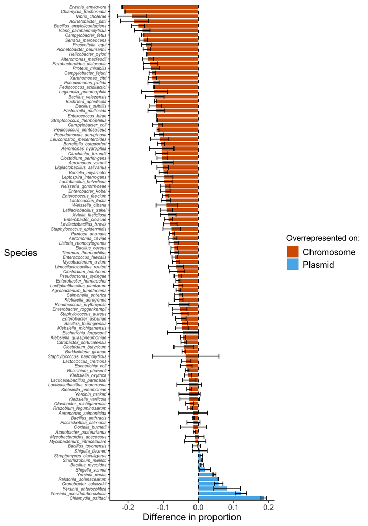

Figure 4.1: The difference in proportion of cooperative genes, as defined using all three modules of SOCfinder, on plasmids compared to chromosomes. Each bar is the mean for a species, and the error bars are the standard error of the mean.